# R Notebook

1 MVP

We want to investigate the avocado dataset, and, in particular, to model the AveragePrice of the avocados. Use the tools we’ve worked with this week in order to prepare your dataset and find appropriate predictors. Once you’ve built your model use the validation techniques discussed on Wednesday to evaluate it.

As part of the MVP we want you not to just run the code but also have a go at interpreting the results and write your thinking in comments in your script.

Hints and tips

region may lead to many dummy variables. Think carefully about whether to include this variable or not (there is no one ‘right’ answer to this!) Think about whether each variable is categorical or numerical. If categorical, make sure that the variable is represented as a factor. We will not treat this data as a time series, so Date will not be needed in your models, but can you extract any useful features out of Date before you discard it? If you want to build a predictive model, consider using either leaps or glmulti to help with this.

```r
library(tidyverse)
library(GGally)
library(modelr)
library(leaps)
library(lubridate)
```

```r
avocado <- read_csv("data/avocado.csv") %>% janitor::clean_names()
summary(avocado)
```

[output not shown]

No NA in any cols, but, total volume doesn’t add up, total bags doesn’t seem to add up. I also looked at the ggpair graph from the folder. some cols are bit skewed, we will deal with they later.

```r
alias(lm(average_price ~ ., data = avocado))
```

```
Model :
average_price ~ x1 + date + total_volume + x4046 + x4225 + x4770 +
    total_bags + small_bags + large_bags + x_large_bags + type +
    year + region
```

```r
# nothing needs to be removed because of alias
```

```r
avocado <- avocado %>% select(-c(x1, region, total_bags, total_volume)) %>%
  mutate(season = case_when(month(date)%in% c(12,1,2) ~"Winter",
                            month(date)%in% c(3,4,5) ~"Spring",
                            month(date)%in% c(6,7,8) ~"Summer",
                            TRUE ~ "Autumn"),
         year = as.factor(year),
         season = as.factor(season),
         type = as.factor(type)) %>%
  select(-date)
# extract seasons from date and get ride of date, remove things that
#I think useless.
```

Split test and train data 20:80

```r
set.seed(9)

test_index <- sample(1:nrow(avocado), size = nrow(avocado)*0.2)

test  <- slice(avocado, test_index)
train <- slice(avocado, -test_index)
```

```r
regsubsets_forward <- regsubsets(average_price ~ ., data = train, nvmax = 9, method = "forward")
summary(regsubsets_forward)
```

```
Subset selection object
Call: regsubsets.formula(average_price ~ ., data = train, nvmax = 9,
    method = "forward")
13 Variables  (and intercept)
             Forced in Forced out
x4046            FALSE      FALSE
x4225            FALSE      FALSE
x4770            FALSE      FALSE
small_bags       FALSE      FALSE
large_bags       FALSE      FALSE
x_large_bags     FALSE      FALSE
typeorganic      FALSE      FALSE
year2016         FALSE      FALSE
year2017         FALSE      FALSE
year2018         FALSE      FALSE
seasonSpring     FALSE      FALSE
seasonSummer     FALSE      FALSE
seasonWinter     FALSE      FALSE
1 subsets of each size up to 9
Selection Algorithm: forward
         x4046 x4225 x4770 small_bags large_bags x_large_bags
1  ( 1 ) " "   " "   " "   " "        " "        " "
2  ( 1 ) " "   " "   " "   " "        " "        " "
3  ( 1 ) " "   " "   " "   " "        " "        " "
4  ( 1 ) " "   " "   " "   " "        " "        " "
5  ( 1 ) "*"   " "   " "   " "        " "        " "
6  ( 1 ) "*"   "*"   " "   " "        " "        " "
7  ( 1 ) "*"   "*"   " "   " "        " "        " "
8  ( 1 ) "*"   "*"   " "   " "        " "        " "
9  ( 1 ) "*"   "*"   " "   " "        " "        " "
         typeorganic year2016 year2017 year2018 seasonSpring
1  ( 1 ) "*"         " "      " "      " "      " "
2  ( 1 ) "*"         " "      "*"      " "      " "
3  ( 1 ) "*"         " "      "*"      " "      " "
4  ( 1 ) "*"         " "      "*"      " "      "*"
5  ( 1 ) "*"         " "      "*"      " "      "*"
6  ( 1 ) "*"         " "      "*"      " "      "*"
7  ( 1 ) "*"         " "      "*"      "*"      "*"
8  ( 1 ) "*"         " "      "*"      "*"      "*"
9  ( 1 ) "*"         "*"      "*"      "*"      "*"
         seasonSummer seasonWinter
1  ( 1 ) " "          " "
2  ( 1 ) " "          " "
3  ( 1 ) " "          "*"
4  ( 1 ) " "          "*"
5  ( 1 ) " "          "*"
6  ( 1 ) " "          "*"
7  ( 1 ) " "          "*"
8  ( 1 ) "*"          "*"
9  ( 1 ) "*"          "*"
```

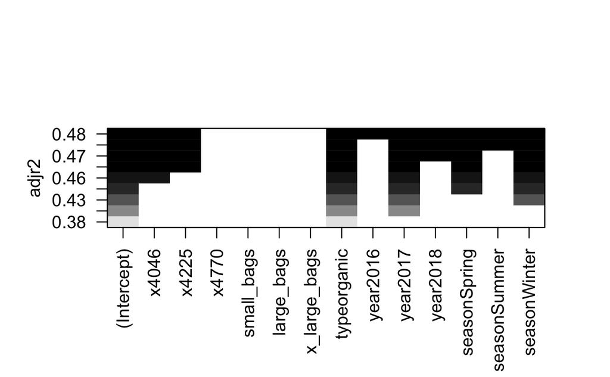

```r
plot(regsubsets_forward, scale = "adjr2")
```

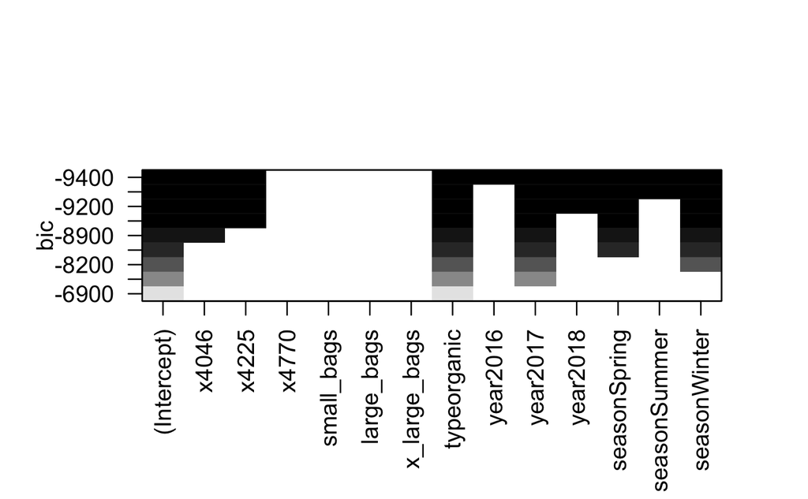

```r
plot(regsubsets_forward, scale = "bic")
```

check the 9th one, which looks the best (highest r2 and lowest bic)

```r
summary(regsubsets_forward)$which[9,]
```

```
 (Intercept)        x4046        x4225        x4770   small_bags
        TRUE         TRUE         TRUE        FALSE        FALSE
  large_bags x_large_bags  typeorganic     year2016     year2017
       FALSE        FALSE         TRUE         TRUE         TRUE
    year2018 seasonSpring seasonSummer seasonWinter
        TRUE         TRUE         TRUE         TRUE
```

```r
mod_1 <- lm(average_price ~ x4046 + x4225 + type + year + season, data = train)
summary(mod_1)
```

```
Call:
lm(formula = average_price ~ x4046 + x4225 + type + year + season,
    data = train)

Residuals:
     Min       1Q   Median       3Q      Max
-1.26049 -0.18200 -0.01233  0.17440  1.54464

Coefficients:
               Estimate Std. Error t value Pr(>|t|)
(Intercept)   1.256e+00  6.694e-03 187.655  < 2e-16 ***
x4046        -9.925e-08  5.031e-09 -19.730  < 2e-16 ***
x4225         8.822e-08  5.307e-09  16.624  < 2e-16 ***
typeorganic   4.857e-01  4.957e-03  97.984  < 2e-16 ***
year2016     -3.728e-02  6.157e-03  -6.054 1.44e-09 ***
year2017      1.447e-01  6.115e-03  23.657  < 2e-16 ***
year2018      7.846e-02  1.042e-02   7.530 5.38e-14 ***
seasonSpring -1.865e-01  6.975e-03 -26.730  < 2e-16 ***
seasonSummer -6.857e-02  7.092e-03  -9.668  < 2e-16 ***
seasonWinter -2.394e-01  6.973e-03 -34.331  < 2e-16 ***
---
Signif. codes:  0 ‘***’ 0.001 ‘**’ 0.01 ‘*’ 0.05 ‘.’ 0.1 ‘ ’ 1

Residual standard error: 0.2911 on 14590 degrees of freedom
Multiple R-squared:  0.4767,    Adjusted R-squared:  0.4764
F-statistic:  1477 on 9 and 14590 DF,  p-value: < 2.2e-16
```

```r
autoplot(mod_1)
```

[output not shown]

I shouldn’t have done this, I should go back changed my train data, But I am going to test this new model see if it improves anything, so I don’t want to break my mod1.

I can also use log but I had 0 in them, I don’t want to get ride of my data at this point (as I have split the data already) So i squared them.

```r
train_1 <- train %>% mutate(x4046 = (x4046)^2,
                 x4225 = (x4225)^2,
                 x4770 = (x4770)^2)
```

```r
regsubsets_forward_1 <- regsubsets(average_price ~ ., data = train_1, nvmax = 9, method = "forward")


summary(regsubsets_forward_1)
```

```
Subset selection object
Call: regsubsets.formula(average_price ~ ., data = train_1, nvmax = 9,
    method = "forward")
13 Variables  (and intercept)
             Forced in Forced out
x4046            FALSE      FALSE
x4225            FALSE      FALSE
x4770            FALSE      FALSE
small_bags       FALSE      FALSE
large_bags       FALSE      FALSE
x_large_bags     FALSE      FALSE
typeorganic      FALSE      FALSE
year2016         FALSE      FALSE
year2017         FALSE      FALSE
year2018         FALSE      FALSE
seasonSpring     FALSE      FALSE
seasonSummer     FALSE      FALSE
seasonWinter     FALSE      FALSE
1 subsets of each size up to 9
Selection Algorithm: forward
         x4046 x4225 x4770 small_bags large_bags x_large_bags
1  ( 1 ) " "   " "   " "   " "        " "        " "
2  ( 1 ) " "   " "   " "   " "        " "        " "
3  ( 1 ) " "   " "   " "   " "        " "        " "
4  ( 1 ) " "   " "   " "   " "        " "        " "
5  ( 1 ) " "   " "   " "   " "        " "        " "
6  ( 1 ) " "   " "   " "   " "        "*"        " "
7  ( 1 ) " "   " "   " "   " "        "*"        " "
8  ( 1 ) " "   "*"   " "   " "        "*"        " "
9  ( 1 ) " "   "*"   " "   " "        "*"        " "
         typeorganic year2016 year2017 year2018 seasonSpring
1  ( 1 ) "*"         " "      " "      " "      " "
2  ( 1 ) "*"         " "      "*"      " "      " "
3  ( 1 ) "*"         " "      "*"      " "      " "
4  ( 1 ) "*"         " "      "*"      " "      "*"
5  ( 1 ) "*"         " "      "*"      " "      "*"
6  ( 1 ) "*"         " "      "*"      " "      "*"
7  ( 1 ) "*"         " "      "*"      "*"      "*"
8  ( 1 ) "*"         " "      "*"      "*"      "*"
9  ( 1 ) "*"         "*"      "*"      "*"      "*"
         seasonSummer seasonWinter
1  ( 1 ) " "          " "
2  ( 1 ) " "          " "
3  ( 1 ) " "          "*"
4  ( 1 ) " "          "*"
5  ( 1 ) "*"          "*"
6  ( 1 ) "*"          "*"
7  ( 1 ) "*"          "*"
8  ( 1 ) "*"          "*"
9  ( 1 ) "*"          "*"
```

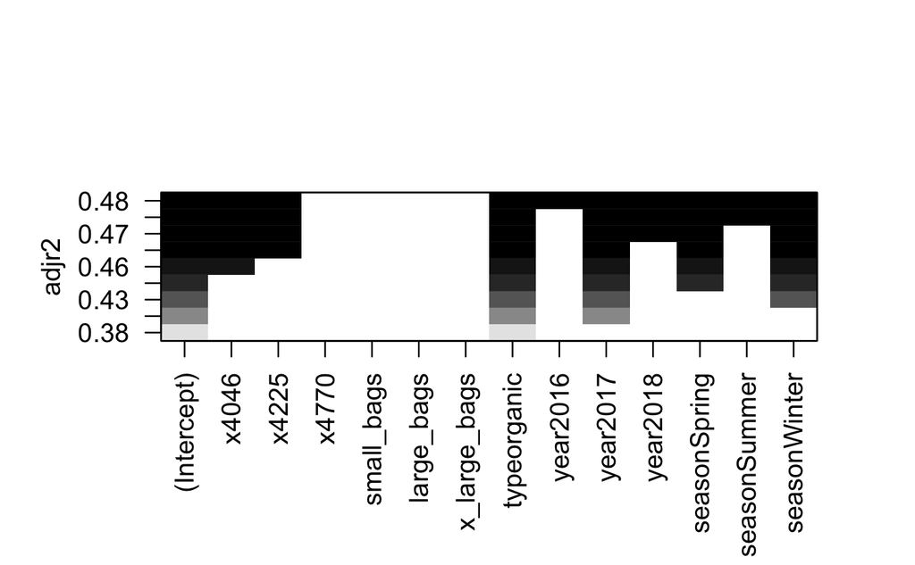

```r
plot(regsubsets_forward, scale = "adjr2")
```

```r
mod_2 <- lm(average_price ~ x4046 + x4225 + type + year + season, data = train_1)
summary(mod_2)
```

```
Call:
lm(formula = average_price ~ x4046 + x4225 + type + year + season,
    data = train_1)

Residuals:
     Min       1Q   Median       3Q      Max
-1.25747 -0.18744 -0.00951  0.17753  1.54174

Coefficients:
               Estimate Std. Error t value Pr(>|t|)
(Intercept)   1.254e+00  6.700e-03 187.120  < 2e-16 ***
x4046        -1.567e-15  4.491e-16  -3.489 0.000486 ***
x4225         9.793e-16  4.828e-16   2.028 0.042549 *
typeorganic   4.909e-01  4.910e-03  99.970  < 2e-16 ***
year2016     -3.625e-02  6.237e-03  -5.811 6.34e-09 ***
year2017      1.417e-01  6.192e-03  22.881  < 2e-16 ***
year2018      7.395e-02  1.055e-02   7.006 2.56e-12 ***
seasonSpring -1.887e-01  7.066e-03 -26.710  < 2e-16 ***
seasonSummer -7.127e-02  7.184e-03  -9.921  < 2e-16 ***
seasonWinter -2.388e-01  7.063e-03 -33.805  < 2e-16 ***
---
Signif. codes:  0 ‘***’ 0.001 ‘**’ 0.01 ‘*’ 0.05 ‘.’ 0.1 ‘ ’ 1

Residual standard error: 0.2949 on 14590 degrees of freedom
Multiple R-squared:  0.4631,    Adjusted R-squared:  0.4627
F-statistic:  1398 on 9 and 14590 DF,  p-value: < 2.2e-16
```

```r
autoplot(mod_2)
```

[output not shown]

No improve for mod2, I will use mod1.

checking my mod1 with testing data

```r
predictions_test <- test %>%
  add_predictions(mod_1) %>%
  select(average_price, pred)
```

```r
mse_test <- mean((predictions_test$pred - test$average_price)**2)
mse_test
```

```
[1] 0.0831129
```

```r
predictions_train <- train %>%
  add_predictions(mod_1) %>%
  select(average_price, pred)
```

```r
mse_train <- mean((predictions_train$pred - train$average_price)**2)
mse_train
```

```
[1] 0.08468046
```